# Scientific Computing with Python

**Scientific Computing with Python**

|  | Prof. Seungchul Lee iSystems Design Lab UNIST http://isystems.unist.ac.kr/ |
| --- | --- |

## Problem

Write a m-code to create an output matrix Y which consists of only even numbers (in order) from the given input X.

For example,

- Input X = [1, 2, …,10]
- Output Y = [2, 4,…,10]

```python
import numpy as np
import matplotlib.pyplot as plt
from numpy.linalg import *
from pylab import *

%matplotlib inline
```

```python
X = np.linspace(1, 10, 10)
n = len(X)
Y = []

for i in range(0,n):
    if X[i]%2 == 0:
        Y.append(X[i])

print(X)
print(Y)
```

```
[  1.   2.   3.   4.   5.   6.   7.   8.   9.  10.]
[2.0, 4.0, 6.0, 8.0, 10.0]
```

## Problem

Given an integer $n$, write a m-code to compute the following:

$$S = 1 + \frac{1}{2} + … + \frac{1}{n}$$

```python
# first method

n = 10
m = np.zeros((1,n))

for i in range(0,n):
    m[0][i] = 1/(i+1)

S = sum(m[0])

print(S)
```

```
2.92896825397
```

```python
# second method

n = 10
temp_sum = 0

for i in range(0,n):
    temp_sum = temp_sum + 1/(i+1)

S = temp_sum

print(S)
```

```
2.9289682539682538
```

## Problem

Plot $\;f(t) = \frac{3}{2} \sin^2(t) + 3 \cos^2(t) + 1\;$ for $\;0\leq t \leq 3$, and find $\,t\,$ that minimizes $f(t)$.

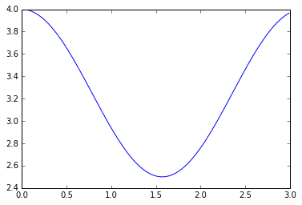

```
1.57
```

```python
t = np.arange(0.0,3.0,0.01)
x1 = np.sin(t)
x2 = np.cos(t)

a1 = 1.5
a2 = 3
a3 = 1

f = a1*(x1**2) + a2*(x2**2) + a3

plt.plot(t,f)
plt.show()

def min(f):
    I = 0
    Y = f[0]
    for i in range(1,len(f)):
        if f[i] < Y:
            Y = f[i]
            I = i
    return Y, I

Y,I = min(f)
print(t[I])
```

## Problem

Plot $\;f(x) = \sin{x} \cdotp e^x + \log_{10}(3x) + \frac{1}{\sqrt{2x + 7}}\;$ for $\;0 \leq x \leq \pi$, and find $x$ that maximizes $f(x)$.

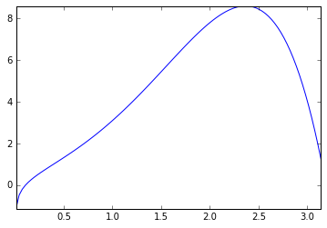

```python
x = np.linspace(0.01,np.pi,100)
y = np.sin(x)*np.exp(x) + np.log10(3*x) + 1/np.sqrt(2*x + 7)

plt.plot(x,y)
plt.axis('tight')
plt.show()
```

## Problem

$M = \begin{bmatrix} 1 & 4 & -3\\ 4 & 2 & 0\\ -3 & 0 & 3 \end{bmatrix}$, calculate $\left(M^TM\right)^{-1}M^2$

```python
M = np.array([[1,4,-3],[4,2,0],[-3,0,3]])

print(np.dot(M.T,M))
print(linalg.inv(np.dot(M.T,M)))

print(np.dot(linalg.inv(np.dot(M.T,M)),np.dot(M,M)))
```

```
[[ 26  12 -12]
 [ 12  20 -12]
 [-12 -12  18]]
[[ 0.06       -0.02        0.02666667]
 [-0.02        0.09        0.04666667]
 [ 0.02666667  0.04666667  0.10444444]]
[[  1.00000000e+00   5.55111512e-17  -5.55111512e-17]
 [  1.11022302e-16   1.00000000e+00   0.00000000e+00]
 [  0.00000000e+00   2.22044605e-16   1.00000000e+00]]
```

## Problem

We want to write code for calculating $S_n = 1 + \frac{1}{2} + \frac{1}{2^2} + … + \frac{1}{2^n}$

1) $S_n$ if $n=5$

2) find a maximum value of $n$ such that $S_n \leq 1.999$

3) plot $S_n$ with a function of $n \;(\leq 10)$

```python
#1)

n = 5
temp_sum = 0

for i in range(0,n+1):
    temp_sum = temp_sum + 1/(2**i)

Sn = temp_sum

print(Sn)
```

```
1.96875
```

```python
#2)

temp_sum = 0
n = 0

while temp_sum <= 1.999:
    temp_sum = temp_sum + 1/(2**n)
    n = n + 1

print(n - 1)
```

```
10
```

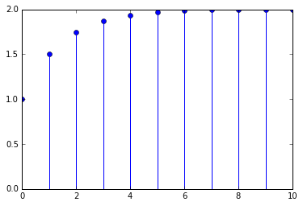

```python
#3)

Sn = []
n = range(0,11)
temp_sum = 0

for i in n:
    temp_sum = temp_sum + 1/(2**i)
    Sn.append(temp_sum)

stem(n,Sn)
plt.show()
```

## Problem

We want to learn about how to numerically take an integral of the given function of $f(x)$.

Calculate $\int^\pi_0 \sin{x}dx$ by using the idea shown in the below figure.

[figure not shown]

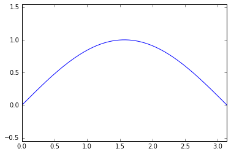

```python
a = 0
b = pi
delta = 0.01
x = np.arange(a,b,delta)
y = np.sin(x)

plt.plot(x,y)
plt.axis('equal')
plt.xlim(x[0],x[len(x)-1])
plt.show()
```

```python
temp_area = 0
for i in range(0,len(x)-1):
    temp_area = temp_area + delta*((y[i]+y[i+1])/2)
print(temp_area)

temp_area2 = 0
for i in range(0,len(x)-1):
    temp_area2 = temp_area2 + delta*y[i]
print(temp_area2)
```

```
1.99998206504
1.99997410178
```

## Problem

We want to learn about how to numerically take a derivative of the given function of $f(x)$.

Calculate $\left.\frac{d\sin{x}}{dx}\right|_{x=0}$ by using the idea shown in the below figure.

[figure not shown]

```python
a = 0
delta = 0.01

dy = (sin(a + delta) - sin(a))/delta

print(dy)
```

```
0.999983333417
```

## Problem

Here, we’d like to numerically find the solutions (roots) of the following equation,

$$f(x) = 4x^3 + 10x^2 - 20x - 10 \quad \text{for} \quad -4 \leq x \leq 3 $$

1) Plot $f(x)$ over $-4 \leq x \leq 3$

2) Numerically find all the roots (solutions) of $f(x) = 0$ with a hint of the below figure.

[figure not shown]

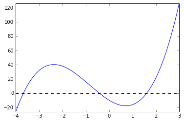

```python
# 1)

x = np.arange(-4.0,3.0,0.01)
y = 4*x**3 + 10*x**2 - 20*x -10

plt.plot(x,y)
plt.plot(x,np.zeros(x.shape),'k--')
plt.axis('tight')
plt.show()
```

```python
sol = []

for i in range(0,len(x)-1):
    if y[i]*y[i+1] <= 0:
        sol.append(x[i])

print(sol)
```

```
[-3.6800000000000068, -0.4300000000000761, 1.5999999999998806]
```

```python
# 2)

f2 = [4,10,-20,-10]
x = roots(f2)

print(x)
```

```
[-3.67534358  1.60037444 -0.42503086]
```

```python
from sympy.solvers import solve
from sympy import Symbol

# 3)
x = Symbol('x')
sol = solve(4*x**3 + 10*x**2 - 20*x - 10, x)

print(sol[0]) # hard to read
```

```
-5/6 - 85/(12*(-1/2 - sqrt(3)*I/2)*(305/8 + 15*sqrt(579)*I/4)**(1/3)) - (-1/2 - sqrt(3)*I/2)*(305/8 + 15*sqrt(579)*I/4)**(1/3)/3
```

```python
def soltofloat(sol):
    result = []
    for i in range(0,len(sol)):
        s = str(sol[i]).replace('I', '1j')
        result.append(float(np.real(eval(s))))
    return result

print(soltofloat(sol))
```

```
[-0.42503085522966266, 1.6003744359991185, -3.675343580769456]
```

## Problem

Run the following code which explains how to make a kind of animation effect in Python.

```python
# this is an animation.
# run it in a different python IDE, (for example, pyCharm).

import numpy as np
import matplotlib.pyplot as plt

plt.axis([-1,1,-4,0.5])
plt.ion()

for x in np.arange(-1.0,1.0,0.05):
    y = -4.0*x**2
    plt.plot(x,y,'ks')
    plt.pause(0.1)

while True:
    plt.pause(0.1)
```

```python
# this is an animation.
# run it in a different python IDE, (for example, pyCharm).

import numpy as np
import matplotlib.pyplot as plt

x = np.arange(0.0,2*np.pi,0.01)

for i in range(1,11):
    y = 1/i*np.sin(x)
    plt.plot(x,y)
    plt.xlim(0.0, 2 * np.pi)
    plt.pause(0.5)

while True:
    plt.pause(0.5)
```

## Problem

Write a code to create a circle as shown in the below figure. (hint: there are many ways to realize this problem, but think about Euler’s formula (http://en.wikipedia.org/wiki/Euler's_formula))

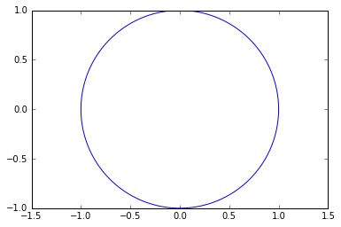

```python
theta = np.arange(0.0,2*np.pi,0.01)

x = np.cos(theta)
y = np.sin(theta)

plt.plot(x,y)
plt.axis('equal')
plt.show()
```

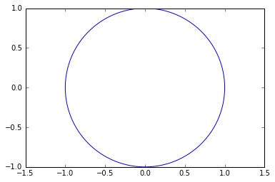

```python
theta = np.arange(0.0,2*np.pi,0.01)
z = np.cos(theta) + 1j*sin(theta)

plt.plot(np.real(z),np.imag(z))
plt.axis('equal')
plt.show()
```

```python
# this is an animation.
# run it in a different python IDE, (for example, pyCharm).

import numpy as np
from matplotlib import pyplot as plt
from matplotlib import animation

fig = plt.figure()
ax = plt.axes(xlim=(-2, 8), ylim=(-1, 1))
ax.set_aspect('equal')
circle, = ax.plot([], [], 'b')
line, = ax.plot([], [], 'y')
sinusoidal, = ax.plot([], [], 'r')
point1, = ax.plot([], [], 'bo')
point2, = ax.plot([], [], 'yo')
point3, = ax.plot([], [], 'ro')

frame = 200

theta = np.linspace(0.0,2*np.pi,frame)
z = np.cos(theta) + 1j*np.sin(theta)

def init():
    circle.set_data([], [])
    line.set_data([], [])
    sinusoidal.set_data([], [])
    point1.set_data([], [])
    point2.set_data([], [])
    point3.set_data([], [])
    return circle, line, sinusoidal, point1, point2, point3

def animate(i):
    global z
    global theta
    x = i * 2*np.pi/200.0
    w = np.cos(x) + 1j*np.sin(x)
    circle.set_data(np.real(z), np.imag(z))
    line.set_data([1,1],[1,-1])
    sinusoidal.set_data(theta, np.imag(z))
    point1.set_data(np.real(w),np.imag(w))
    point2.set_data(1, np.imag(w))
    point3.set_data(x, np.imag(w))
    return circle, line, sinusoidal, point1, point2, point3

anim = animation.FuncAnimation(fig, animate, init_func=init,
                               frames=frame, interval=20, blit=True)

plt.show()
```

## Problem

Create an animation which the green dot is moving around the unit circle (counter clockwise).

```python
# this is an animation.
# run it in a different python IDE, (for example, pyCharm).

import numpy as np
from matplotlib import pyplot as plt
from matplotlib import animation

fig = plt.figure()
ax = plt.axes(xlim=(-5, 5), ylim=(-1, 1))
ax.set_aspect('equal')
circle, = ax.plot([], [], 'b')
point1, = ax.plot([], [], 'go')

frame = 200

theta = np.linspace(0.0,2*np.pi,frame)
z = np.cos(theta) + 1j*np.sin(theta)

def init():
    circle.set_data([], [])
    point1.set_data([], [])
    return circle, point1

def animate(i):
    global z
    x = i * 2*np.pi/200.0
    w = np.cos(x) + 1j*np.sin(x)
    circle.set_data(np.real(z), np.imag(z))
    point1.set_data(np.real(w),np.imag(w))
    return circle, point1

anim = animation.FuncAnimation(fig, animate, init_func=init,
                               frames=frame, interval=20, blit=True)

plt.show()
```

```python
# this is an animation.
# run it in a different python IDE, (for example, pyCharm).

import numpy as np
from matplotlib import pyplot as plt
from matplotlib import animation

fig = plt.figure()
ax = plt.axes(xlim=(-5, 5), ylim=(-1, 1))
ax.set_aspect('equal')
circle, = ax.plot([], [], 'b')
trajectory, = ax.plot([], [], 'y')
point1, = ax.plot([], [], 'go')

frame = 200

theta = np.linspace(0.0,2*np.pi,frame)
z = np.cos(theta) + 1j*np.sin(theta)

def init():
    circle.set_data([], [])
    trajectory.set_data([], [])
    point1.set_data([], [])
    return circle, trajectory, point1

def animate(i):
    global z
    x = i * 2*np.pi/200.0
    w = np.cos(x) + 1j*np.sin(x)
    circle.set_data(np.real(z[i:199]), np.imag(z[i:199]))
    trajectory.set_data(np.real(z[0:i]), np.imag(z[0:i]))
    point1.set_data(np.real(w),np.imag(w))
    return circle, trajectory, point1

anim = animation.FuncAnimation(fig, animate, init_func=init,
                               frames=frame, interval=20, blit=True)

plt.show()
```

## Problem

We want to explore a cycloid (refer to http://en.wikipedia.org/wiki/Cycloid for more information). A cycloid is the curve traced by a point on the rim of a circular wheel as the wheel rolls along a straight line.

[figure not shown]

1) Create a code to plot the cycloid trajectory. Remember there are many ways to do it.

2) Create a code to animate a cycloid by a rolling unit circle.

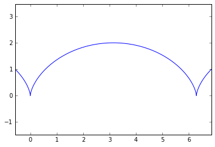

```python
theta = np.arange(-np.pi/2,5/2*np.pi,0.01)

x = theta - np.sin(theta)
y = 1 - np.cos(theta)

plt.plot(x,y)
plt.axis('equal')
plt.xlim([x[0],x[len(theta)-1]])
plt.show()
```

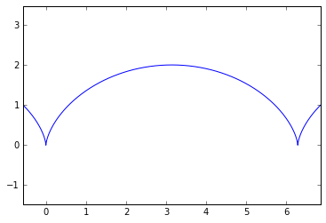

```python
theta = np.arange(-np.pi/2,5/2*np.pi,0.01)

z = theta + 1j - np.sin(theta) - 1j*np.cos(theta)

plt.plot(np.real(z),np.imag(z))
plt.axis('equal')
plt.xlim([np.real(z[0]),np.real(z[len(z)-1])])
plt.show()
```

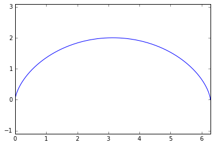

```python
theta = np.arange(0.0,2*np.pi,0.01)

z = theta + 1j + np.exp(1j*(3*np.pi/2-theta))

plt.plot(np.real(z),np.imag(z))
plt.axis('equal')
plt.xlim([np.real(z[0]),np.real(z[len(z)-1])])
plt.show()
```

```python
# this is an animation.
# run it in a different python IDE, (for example, pyCharm).

import numpy as np
from matplotlib import pyplot as plt
from matplotlib import animation

fig = plt.figure()
ax = plt.axes(xlim=(-5, 10), ylim=(-1, 3))
ax.set_aspect('equal')
line, = ax.plot([], [], 'k')
circle, = ax.plot([], [], 'b')
trajectory, = ax.plot([], [], 'r--')
point1, = ax.plot([], [], 'go')

frame = 200

theta = np.linspace(0.0,2*np.pi,frame)
z = theta + 1j + np.exp(1j*(3*np.pi/2-theta))
c = 1j + np.exp(1j*theta)

def init():
    line.set_data([], [])
    circle.set_data([], [])
    trajectory.set_data([], [])
    point1.set_data([], [])
    return line, circle, trajectory, point1

def animate(i):
    global z, c, frame
    theta = i*2*np.pi/frame
    w = theta + 1j + np.exp(1j*(3*np.pi/2-theta))
    line.set_data([-1,2*np.pi+1],[0,0])
    circle.set_data(theta + np.real(c),np.imag(c))
    trajectory.set_data(np.real(z),np.imag(z))
    point1.set_data(np.real(w),np.imag(w))
    return line, circle, trajectory, point1

anim = animation.FuncAnimation(fig, animate, init_func=init,
                               frames=frame, interval=20, blit=True)

plt.show()
```

## Problem

Let's try more complicated one, hypotrochoid (http://en.wikipedia.org/wiki/Hypotrochoid).

[figure not shown]

1) Write a code to plot the cycloid trajectory with $r = 0.1, 0.2, 0.3, \cdots,0.9$

2) Animate the hypotrochoid with two circles (unit circle and circle with radius $r$ )

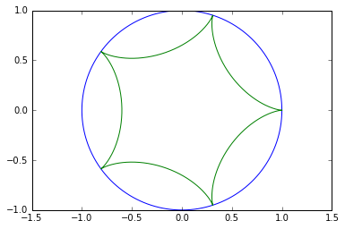

```python
theta = np.arange(0.0,2*np.pi,0.01)

c = np.exp(1j*theta)
r = 0.2
beta = 2*np.pi + theta*(1-1/r)
z = (1-r)*np.exp(1j*theta) + r*np.exp(1j*beta)

plt.plot(np.real(c),np.imag(c))
plt.plot(np.real(z),np.imag(z))
plt.axis('equal')
plt.show()
```

```python
# this is an animation.
# run it in a different python IDE, (for example, pyCharm).

import numpy as np
from matplotlib import pyplot as plt
from matplotlib import animation

fig = plt.figure()
ax = plt.axes(xlim=(-5, 5), ylim=(-1, 1))
ax.set_aspect('equal')
circle1, = ax.plot([], [], 'k')
circle2, = ax.plot([], [], 'r')
trajectory, = ax.plot([], [], 'b')
point1, = ax.plot([], [], 'go')

frame = 200

k = 4*np.pi

r = 0.4
theta = np.linspace(0.0,k,frame)
beta = 2*np.pi + theta*(1-1/r)
c = np.exp(1j*theta)
z = (1-r)*np.exp(1j*theta) + r*np.exp(1j*beta)

def init():
    circle1.set_data([], [])
    circle2.set_data([], [])
    trajectory.set_data([], [])
    point1.set_data([], [])
    return circle1, circle2, trajectory, point1

def animate(i):
    global c, z, frame
    x = i*k/frame
    c2 = (1-r)*np.exp(1j*x) + r*np.exp(1j*theta)
    w = (1-r)*np.exp(1j*x) + r*np.exp(1j*(2*np.pi + x*(1-1/r)))
    circle1.set_data(np.real(c),np.imag(c))
    circle2.set_data(np.real(c2),np.imag(c2))
    trajectory.set_data(np.real(z),np.imag(z))
    point1.set_data(np.real(w),np.imag(w))
    return circle1, circle2, trajectory, point1

anim = animation.FuncAnimation(fig, animate, init_func=init,
                               frames=frame, interval=20, blit=True)

plt.show()
```

## Problem

We want to numerically compute $\pi$ in various ways. Utilize the following equations to write codes. For your reference, the website (http://en.wikipedia.org/wiki/Pi) provides thoughtful backgrounds of how to compute $\pi$.

1) $\int^\infty_{-\infty} \frac{1}{1+x^2} dx = \pi$

2) $\frac{2}{\pi} = \frac{\sqrt{2}}{2} \cdot \frac{\sqrt{2+\sqrt{2}}}{2} \cdot \frac{\sqrt{2+\sqrt{2+\sqrt{2}}}}{2} \cdots$

3) $\pi = \frac{4}{1} - \frac{4}{3} + \frac{4}{5} - \frac{4}{7} + \frac{4}{9} - \frac{4}{11} + \cdots$

```python
n = 10000.0
dx = 0.01
x = np.arange(-n,n,dx)

temp_sum = 0
for i in range(0,len(x)):
    temp_sum += dx*(1/(x[i]**2+1))

print(temp_sum)
```

```
3.14139265352
```

```python
r = 0.0
temp_prod = 1.0

for i in range(0, 10):
    r = np.sqrt(2+r)
    temp_prod *= r/2

print(2/temp_prod)
```

```
3.14159142151
```

```python
n = 10000
x = np.arange(1, n, 2)

temp_sum = 0
for i in range(0,len(x)):
    temp_sum = temp_sum + (-1)**i*4/x[i]

print(temp_sum)
```

```
3.14139265359
```

## Problem

In this problem, we still want to calculate $\pi$ , but it will be a totally different approach, Monte Carlo (MC) methods (probabilistic interpretation). Read the section of the introduction part in the Wikipedia (http://en.wikipedia.org/wiki/Monte_Carlo_method) to understand a fundamental concept of Monte Carlo. Try to understand MC with the given code.

1) Draw a square on the ground, then inscribe a circle within it.

2) Uniformly scatter some objects of uniform size (grains of rice or sand) over the square.

3) Count the number of objects inside the circle and the total number of objects. The ratio of the two counts is an estimate of the ratio of the two areas, which is $\pi$/4.

4) Multiply the result by 4 to estimate $\pi$.

```
3.1416
```

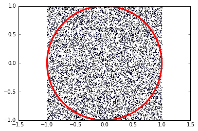

```python
n = 10000
x = -1 + 2*np.random.rand(n,2)
count = 0
for j in range(0,n):
    if np.linalg.norm(x[j,:]) <= 1 :
        count = count + 1

pi_est = (count/n)*4
print(pi_est)

# visualize
w = np.arange(0.0,2*np.pi,0.01)
z = np.cos(w) + 1j*np.sin(w)


plt.plot(x[:,0],x[:,1],'bo',ms = 1)
plt.plot(np.real(z),np.imag(z),'r',lw=3)
plt.axis('equal')
plt.show()
```